# figure 1bc: Comparing ChIP-nexus and ChIP-seq of Oct4 and Sox2

Melanie (1028-02098-001-001)

September 30, 2020

# Introduction

# Computational Setup

```r
#Standard packages
library(rtracklayer) ; library(GenomicRanges); library(magrittr) ; library(Biostrings)
library(ggplot2) ; library(reshape2); library(plyranges); library(Rsamtools); library(data.table)
library(BSgenome.Mmusculus.UCSC.mm10); library(plyr); library(viridis); library(dplyr)

#KNITR Options
setwd("/n/projects/mw2098/publications/2019_bpnet/")
options(knitr.figure_dir="figures/15-fig1bc-oct4-sox2-comparison", width=16, height=20)

#Lab sources
source("rscripts/granges_common.r")
source("rscripts/metapeak_common.r")
source("rscripts/knitr_common.r")
source("rscripts/caching.r")
source("rscripts/multiplot.R")

#Specific packages
library(grid)
library(lattice)
library(gtable)
library(latticeExtra)
library(gridExtra)
library(Hmisc)
library(grid)
library(gridExtra)
```

# Define data paths

ChIP samples were normalized WRT reads per million (RPM).

```r
manuscript_path<-"../../analysis/bpnet/publication/manuscript/mitra.stanford.edu/kundaje/avsec/chipnexus/paper/data/"

# Nexus: manuscript, Seq: zeitlingerlab
samples.list<-list(nexus = list(oct4 = list(pos = file.path(manuscript_path, "chip-nexus/Oct4/counts.pos.bw"),
                                            neg = file.path(manuscript_path, "chip-nexus/Oct4/counts.neg.bw")),
                                sox2 = list(pos = file.path(manuscript_path, "chip-nexus/Sox2/counts.pos.bw"),
                                            neg = file.path(manuscript_path, "chip-nexus/Sox2/counts.neg.bw"))),
                   chip = list (oct4 = list(rep1 = "data/bw/seq/mesc_oct4_seq_1_normalized.bw",
                                            rep2 = "data/bw/seq/mesc_oct4_seq_2_normalized.bw"),
                                sox2 = list(rep1 = "data/bw/seq/mesc_sox2_seq_1_normalized.bw",
                                            rep2 = "data/bw/seq/mesc_sox2_seq_2_normalized.bw")))
```

# Locate regions

These motifs are derived from previous de novo motif analysis in the lab and previous literature defining these canonical motifs (TherMos: Estimating protein–DNA binding energies from in vivo binding profiles, 2013).

```r
sox2_motif <- DNAString("RGRACAAWRGV") %>%
  vmatchPattern(., BSgenome.Mmusculus.UCSC.mm10, max.mismatch =0, fixed = "subject")
sox2oct4_motif <- DNAString("SYWTTGTNATGCAAA") %>%
  vmatchPattern(., BSgenome.Mmusculus.UCSC.mm10, max.mismatch =0, fixed = "subject")
sox2oct4_1mm_motif <- DNAString("SYWTTGTNATGCAAA") %>%
  vmatchPattern(., BSgenome.Mmusculus.UCSC.mm10, max.mismatch =1, fixed = "subject")
```

# Calculate counts

In order to find the strongest peaks for the representative plots, we will count the reads occurring at a 100bp region for each sample.

```r
#remove ChrM from Sox2 site
sox2_motif<-sox2_motif %>% keepStandardChromosomes(pruning.mode = "coarse", species = "Mus_musculus")
sox2_motif<-sox2_motif[seqlevels(sox2_motif) != "chrM"]
seqlevels(sox2_motif, pruning.mode="coarse") <- seqlevels(sox2_motif)[-22]

sox2oct4_motif<-sox2oct4_motif %>% keepStandardChromosomes(pruning.mode = "coarse", species = "Mus_musculus")
sox2oct4_1mm_motif<-sox2oct4_1mm_motif %>% keepStandardChromosomes(pruning.mode = "coarse", species = "Mus_musculus")

sox2_motif$sox2_signals<-abs(regionSums(regions = resize(sox2_motif, 100, fix="center"), cvg = samples.list$nexus$sox2$pos)) +
  abs(regionSums(regions = resize(sox2_motif, 100, fix="center"), cvg = samples.list$nexus$sox2$neg))
sox2oct4_motif$oct4_signals<-abs(regionSums(regions = resize(sox2oct4_motif, 100, fix="center"), cvg = samples.list$nexus$oct4$pos)) +
  abs(regionSums(regions = resize(sox2oct4_motif, 100, fix="center"), cvg = samples.list$nexus$oct4$neg))
sox2oct4_1mm_motif$oct4_signals<-abs(regionSums(regions = resize(sox2oct4_1mm_motif, 100, fix="center"), cvg = samples.list$nexus$oct4$pos)) +
  abs(regionSums(regions = resize(sox2oct4_1mm_motif, 100, fix="center"), cvg = samples.list$nexus$oct4$neg))

saveRDS(sox2_motif, "data/rdata/motif_locations/sox2_motif_no_mm.rds")
saveRDS(sox2oct4_motif, "data/rdata/motif_locations/sox2oct4_motif_0_mm.rds")
saveRDS(sox2oct4_1mm_motif, "data/rdata/motif_locations/sox2oct4_motif_1_mm.rds")
```

# Order the data

Order the data based on counts and select top 500 peaks for each motif. Filter Sox2 instances from Sox2-Oct4 motifs.

```r
#Import data
sox2_motif<-readRDS("data/rdata/motif_locations/sox2_motif_no_mm.rds")
sox2oct4_motif<-readRDS("data/rdata/motif_locations/sox2oct4_motif_1_mm.rds")

#Keep overlaps off
sox2_motif<-sox2_motif[-findOverlaps(resize(sox2_motif, 500, "center"), resize(sox2oct4_motif, 500, "center"))@from]

#Select top peaks
ntop<-500
ntop_corrected_for_oct4<-ntop

if(ntop>length(sox2oct4_motif)){ntop_corrected_for_oct4<-length(sox2oct4_motif)}

sox2_motif<-sox2_motif[order(sox2_motif$sox2_signals, decreasing=T)][1:(ntop)]
sox2oct4_motif<-sox2oct4_motif[order(sox2oct4_motif$oct4_signals, decreasing=T)][1:ntop_corrected_for_oct4]

#Define motifs
motif.list<-list(sox2 = sox2_motif,
                 oct4 = sox2oct4_motif)
```

# Get metapeaks

Obtain metapeak profiles as dataframes.

```r
#nexus
nexus_metapeaks<-lapply(c("sox2", "oct4"), function(x){
  lapply(c("sox2", "oct4"), function(y){
      message(x, y)
      peaks<-exo_metapeak(gr = resize(motif.list[[x]], 1, "start"), sample = samples.list$nexus[[y]], upstream = 200, downstream = 200)
      peaks$fac<-y
      peaks$motif<-x
      peaks[,c(1,2,3,6,7)]
  }) %>% rbindlist
}) %>% rbindlist

#seq
seq_metapeaks<-lapply(c("sox2", "oct4"), function(x){
  lapply(c("sox2", "oct4"), function(y){
      peaks<-exo_metapeak(gr = resize(motif.list[[x]], 1, "start"), sample = list(pos=samples.list$chip[[y]]$rep1, neg=samples.list$chip[[y]]$rep2), upstream = 200, downstream = 200)
      peaks<-peaks %>% group_by(tss_distance) %>% dplyr::summarize(reads=sum(abs(reads))) # summarize(reads=sum(abs(reads))/2) #done in original analysis
      peaks$strand<-"*"
      peaks$fac<-y
      peaks$motif<-x
      peaks
  }) %>% rbindlist
}) %>% rbindlist
```

# Plot metapeaks

Plot metapeaks together.

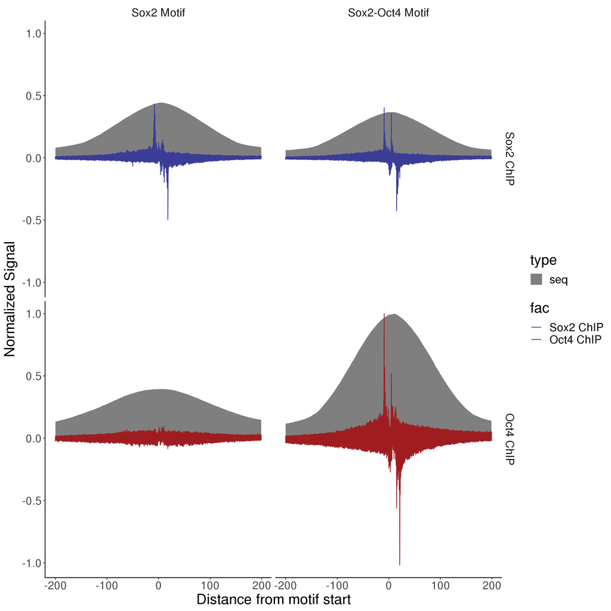

```r
#Normalize and distinguish
nexus_metapeaks$norm_reads<-nexus_metapeaks$reads/max(nexus_metapeaks$reads)
nexus_metapeaks$type<-"nexus"
seq_metapeaks$norm_reads<-seq_metapeaks$reads/max(seq_metapeaks$reads)
seq_metapeaks$type<-"seq"

combined_metapeaks<-rbind(seq_metapeaks, nexus_metapeaks)
combined_metapeaks$fac<-factor(combined_metapeaks$fac, levels=c("sox2", "oct4"), labels=c("Sox2 ChIP", "Oct4 ChIP"))
combined_metapeaks$motif<-factor(combined_metapeaks$motif, levels=c("sox2", "oct4"), labels=c("Sox2 Motif", "Sox2-Oct4 Motif"))
combined_metapeaks$strand<-factor(combined_metapeaks$strand, levels=c("*", "-", "+"))
combined_metapeaks$type<-factor(combined_metapeaks$type, levels=c("seq", "nexus"))
combined_metapeaks$tss_distance<-combined_metapeaks$tss_distance %>% as.character %>% as.numeric

#Plot
showcase<-ggplot(subset(combined_metapeaks, type=="seq"), aes(x=tss_distance, y=norm_reads))+
  geom_area(aes(fill=type), position="identity")+
  geom_line(data=subset(combined_metapeaks, type=="nexus"), aes(color=fac))+
  facet_grid(fac ~ motif)+
  scale_alpha_manual(values = c(.5, 1), guide=F)+
  scale_fill_manual(values = c("grey50"))+
  scale_color_manual(values = c("#3A3C97", "#9F1D20"))+
  xlab("Distance from motif start")+
  ylab("Normalized Signal")+
  theme_classic()+
  theme(text=element_text(size=20), strip.background = element_blank())
print(showcase)
```

```r
#ggsave("figures/showcase/overlay_combined/showcase_of_motifs.pdf", showcase, height=12, width=12)
#
# showcase_line<-ggplot(subset(combined_metapeaks, type=="seq"), aes(x=tss_distance, y=norm_reads))+
#   geom_area(aes(fill=type), position="identity")+
#   geom_line(data=subset(combined_metapeaks, type=="nexus"), aes(color=fac, group=strand))+
#   facet_grid(fac ~ motif)+
#   scale_alpha_manual(values = c(.5, 1), guide=F)+
#   scale_fill_manual(values = c("grey50"))+
#   scale_color_manual(values = c("#3A3C97", "#9F1D20"))+
#   xlab("Distance from motif start")+
#   ylab("Normalized Signal")+
#   theme_classic()+
#   theme(text=element_text(size=20), strip.background = element_blank())
# print(showcase_line)
#
# ggsave("figures/showcase/overlay_combined/showcase_of_motifs_line_plot.pdf", showcase_line, height=12, width=12)
```

# Plot heatmap of ChIP-nexus profiles

In order to show that the metaprofiles are composed of sites that are all strong, we will display a heatmap of the individual regions of Sox2 and Oct4.

## Functions to plot heatmap

```r
#Plot heatmap

#Associated functions
normalize_each_matrix<-function(matrix_list, removal_threshold, normalize_threshold){

  max.per.gene.pos <- apply(matrix_list$pos, 1, function(x){quantile(x, normalize_threshold)})
  min.per.gene.pos <- apply(matrix_list$pos, 1, function(x){quantile(x, removal_threshold)})
  max.per.gene.neg <- apply(matrix_list$neg, 1, function(x){quantile(x, normalize_threshold)})
  min.per.gene.neg <- apply(matrix_list$neg, 1, function(x){quantile(x, removal_threshold)})

  matrix.p <- matrix_list$pos
  matrix.p [matrix.p <= min.per.gene.pos] <- NA #Remove all values that are below 50th percentile
  matrix.p <- pmin(matrix.p / max.per.gene.pos,1) #Re-normalize values that remain.

  matrix.n <- matrix_list$neg
  matrix.n [matrix.n <= min.per.gene.neg] <- NA
  matrix.n <- pmin(matrix.n / max.per.gene.neg,1)
  list(pos=matrix.p, neg=matrix.n)
}

format_matrix_for_heatmap<-function(matrix, strand, downstream, upstream){
  mat<-as.data.frame(matrix)
  colnames(mat)<-as.numeric((-upstream+1):downstream)
  mat$region<-1:nrow(mat)
  df<-melt(mat, id.vars = "region", variable.name="position", value.name="signal", variable.factor = FALSE)
  colnames(df)<-c("region", "position", "signal")
  #Remove NA values
  df<-df[which(!is.na(df$signal)),]
  df$strand<-as.character(strand)
  df$position<-as.numeric(as.character(df$position))
  return(df)
}

#Required inputs:
# regions.gr = GRanges of regions desired to plot across
# sample = list(pos="", neg="") with appropriate filepaths to the nexus bws

#Optional inputs
# order = option that can either be "sum" or "clustering" that will determine how the heatmap gets arranged. Any other value will return the order of the granges as input.
# output_file_name = option that will write the plot to a PDF if a filepath is provided
# reduce = option to reduce the GRanges to remove redundancies
# upstream/downstream = how far you want your heatmap to extend relative to the center of the provided GRanges
# alpha_value = current option to determine color balancing (in progress)
# removal_threshold = quantile value to remove background regions
# normalize_threshold = upper quantile value to keep background regions
# reverse = option to reverse strand (only useful if you are plotting reverse complement of a motif, say)

#Outputs: ggplot with heatmap of regions (xaxis=position, yaxis=regions, fill=quantile normalized chipnexus value)

plot_nexus_heatmap<-function(regions.gr, sample, title="Heatmap of ChIP-nexus Signals", order="sum", output_file_name=NA, reduce=T, upstream=50, downstream=50,
                             alpha_value=.5, removal_threshold=.5, normalize_threshold=0.99, reverse=F, return_only_df = F){
  if(reverse){strand(regions.gr) <- ifelse(strand(regions.gr) == '+', '-', '+')}
  if(reduce){regions.gr<-GenomicRanges::reduce(regions.gr)}
  print(length(regions.gr))

  #Get signals across regions
  mat<-exo_metapeak_matrix(regions.gr = resize(regions.gr, 1, "start"), sample=sample, upstream=upstream, downstream=downstream)

  #Order region rows
  if(order=="clustering"){
    order_of_rows<-hclust(d = (dist(mat$pos+mat$neg))/2)$order
  }
  else if (order=="sum"){
    nrows<-length(mat$pos[,1])
    sum_by_rows_vec<-(apply(mat$pos, 1, sum) + abs(apply(mat$neg, 1, sum)))/2
    order_of_rows<-order(sum_by_rows_vec, decreasing=F)
    # #TODO: Fix row orders
    # print(data.frame(order=order_of_rows, sum_amt=summed_by_row[order_of_rows]))
  }
  else{order_of_rows<-1:length(regions.gr)}

  mat$pos<-mat$pos[order_of_rows, ]
  mat$neg<-mat$neg[order_of_rows, ]

  #Normalize matrix
  norm_mat_matrix<-normalize_each_matrix(matrix_list = mat, removal_threshold =  removal_threshold, normalize_threshold = normalize_threshold)
  #Format matrix
  mat_pos.df<-format_matrix_for_heatmap(matrix = norm_mat_matrix$pos, strand = "pos", downstream = downstream, upstream = upstream)
  mat_neg.df<-format_matrix_for_heatmap(matrix = norm_mat_matrix$neg, strand = "neg", downstream = downstream, upstream = upstream)
  mat_final_df<-rbind(mat_pos.df, mat_neg.df)
  #mat_pos.df$region<-factor(mat_pos.df$region, levels = order_of_rows)
  #mat_neg.df$region<-factor(mat_neg.df$region, levels = order_of_rows)

  if(return_only_df){
    return(mat_final_df)
  }
  else{
    #Plot matrix
    g<-ggplot()+
      geom_tile(data=mat_pos.df, aes(x=position, y=region, fill=signal))+
      geom_tile(data=mat_neg.df, aes(x=position, y=region, fill=-signal), alpha=alpha_value)+
      ggtitle(title, subtitle = length(regions.gr))+
      scale_x_continuous("Position (bp)", expand = expand_scale(mult = c(0, 0)))+
      scale_y_continuous("Regions", expand = expand_scale(mult = c(0, 0)))+
      scale_fill_gradientn(colors = c('#08306b', '#08519c' , '#2171b5', '#4292c6', '#6baed6',
                                      '#9ecae1', '#c6dbef','#deebf7', '#f7fbff', "white", '#fff5f0',
                                      '#fee0d2','#fcbba1','#fc9272','#fb6a4a','#ef3b2c','#cb181d','#a50f15','#67000d'), name = "norm. signal") +
      # scale_fill_gradient2(low="#08306b", mid="white", high="#67000d")+
      theme_classic()+
      theme(text=element_text(size=14), legend.position = "none", panel.grid = element_blank(), panel.border = element_blank())

    if(!is.na(output_file_name)){ggsave(filename = paste(getwd(), output_file_name, sep="/"), plot = g, width = 12, height=12)}
    return(g)
  }
}
```

## Plot heatmaps across top 500 Oct4-Sox2 motif sites

```r
oct4_heatmap<-plot_nexus_heatmap(regions.gr = resize(motif.list$oct4, 1, "start"), sample = samples.list$nexus$oct4, order = "sum", upstream = 200, downstream = 200, title = "Oct4 ChIP-nexus")
```

```
## [1] 500
```

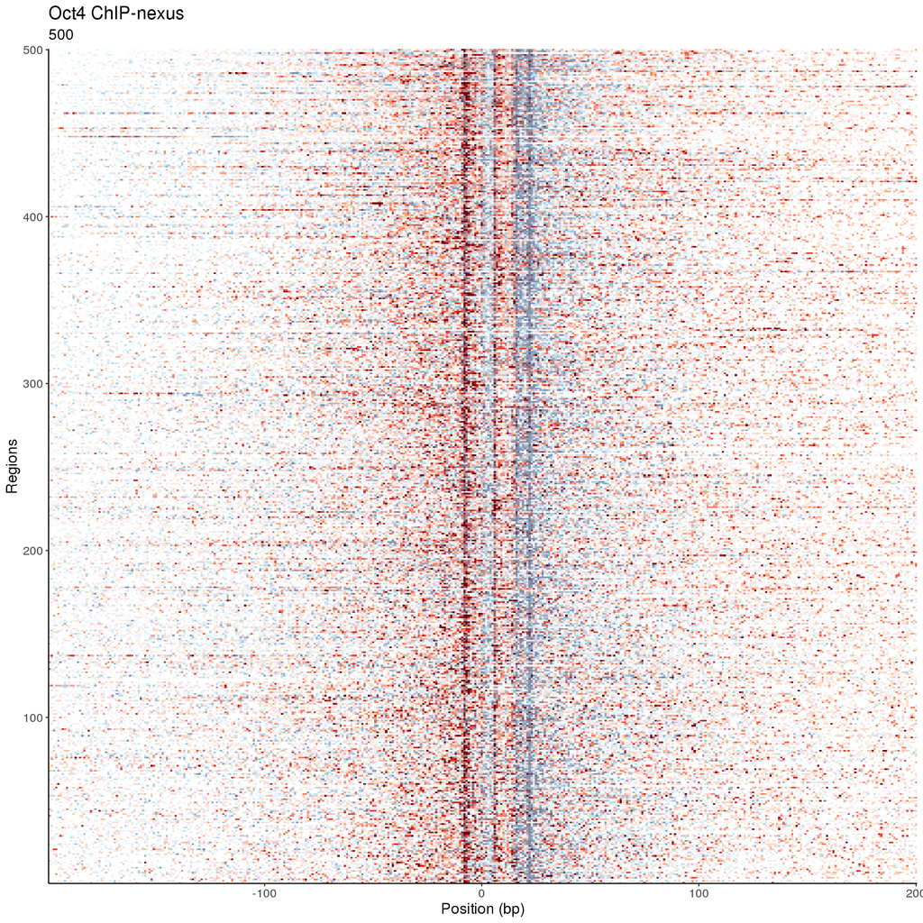

```r
print(oct4_heatmap)
```

```r
sox2_heatmap<-plot_nexus_heatmap(regions.gr = resize(motif.list$sox2, 1, "start"), sample = samples.list$nexus$sox2, order = "sum", upstream = 200, downstream = 200, title = "Sox2 ChIP-nexus")
```

```
## [1] 500
```

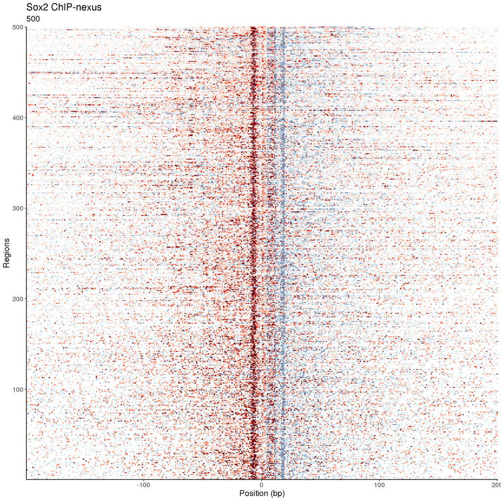

```r
print(sox2_heatmap)
```

```r
#Saved as .png because individual box rendered as PDFs provide very poor image viewing.
ggsave("figures/15-fig1bc-oct4-sox2-comparison/fig1b-oct4sox2-heatmap.png", grid.arrange(oct4_heatmap, sox2_heatmap, ncol = 2), height = 4, width = 6, dpi = "print")
```